# gemstone_project

```python
# import Libraries
import pandas as pd
import numpy as np
import seaborn as sns
import matplotlib.pyplot as plt
```

```python
# Data ingestions step
df=pd.read_csv("gemstone.csv")
df.head()
```

|  | id | carat | cut | color | clarity | depth | table | x | y | z | price |
| --- | --- | --- | --- | --- | --- | --- | --- | --- | --- | --- | --- |
| 0 | 0 | 1.52 | Premium | F | VS2 | 62.2 | 58.0 | 7.27 | 7.33 | 4.55 | 13619 |
| 1 | 1 | 2.03 | Very Good | J | SI2 | 62.0 | 58.0 | 8.06 | 8.12 | 5.05 | 13387 |
| 2 | 2 | 0.70 | Ideal | G | VS1 | 61.2 | 57.0 | 5.69 | 5.73 | 3.50 | 2772 |
| 3 | 3 | 0.32 | Ideal | G | VS1 | 61.6 | 56.0 | 4.38 | 4.41 | 2.71 | 666 |
| 4 | 4 | 1.70 | Premium | G | VS2 | 62.6 | 59.0 | 7.65 | 7.61 | 4.77 | 14453 |

showing features like carat, cut, color, clarity, dimensions, and price. price is the target variable or output

```python
df.isnull().sum()
```

```
id         0
carat      0
cut        0
color      0
clarity    0
depth      0
table      0
x          0
y          0
z          0
price      0
dtype: int64
```

no missing value in data

```python
df.info()
```

```
<class 'pandas.core.frame.DataFrame'>
RangeIndex: 193573 entries, 0 to 193572
Data columns (total 11 columns):
 #   Column   Non-Null Count   Dtype
---  ------   --------------   -----
 0   id       193573 non-null  int64
 1   carat    193573 non-null  float64
 2   cut      193573 non-null  object
 3   color    193573 non-null  object
 4   clarity  193573 non-null  object
 5   depth    193573 non-null  float64
 6   table    193573 non-null  float64
 7   x        193573 non-null  float64
 8   y        193573 non-null  float64
 9   z        193573 non-null  float64
 10  price    193573 non-null  int64
dtypes: float64(6), int64(2), object(3)
memory usage: 16.2+ MB
```

The dataset contains 193,573 entries with 11 columns, all of which are complete with no missing values. It includes a mix of numerical (int64, float64) and categorical (object) features

```python
# drop id column
df=df.drop(labels=['id'],axis=1)
df.head()
```

|  | carat | cut | color | clarity | depth | table | x | y | z | price |
| --- | --- | --- | --- | --- | --- | --- | --- | --- | --- | --- |
| 0 | 1.52 | Premium | F | VS2 | 62.2 | 58.0 | 7.27 | 7.33 | 4.55 | 13619 |
| 1 | 2.03 | Very Good | J | SI2 | 62.0 | 58.0 | 8.06 | 8.12 | 5.05 | 13387 |
| 2 | 0.70 | Ideal | G | VS1 | 61.2 | 57.0 | 5.69 | 5.73 | 3.50 | 2772 |
| 3 | 0.32 | Ideal | G | VS1 | 61.6 | 56.0 | 4.38 | 4.41 | 2.71 | 666 |
| 4 | 1.70 | Premium | G | VS2 | 62.6 | 59.0 | 7.65 | 7.61 | 4.77 | 14453 |

The column 'id' has been successfully dropped from the dataset as it does not contribute to price prediction.

```python
# check for duplicate record
df.duplicated().sum()
```

```
0
```

The dataset contains no duplicate records, confirming that all 193,573 entries are unique.

```python
# separating  numerical and categorical columns

numerical_columns=df.columns[df.dtypes!='object']
categorical_columns=df.columns[df.dtypes=='object']
print("Numerical columns: ",numerical_columns)
print("Categorical columns: ",categorical_columns)
```

```
Numerical columns:  Index(['carat', 'depth', 'table', 'x', 'y', 'z', 'price'], dtype='object')
Categorical columns:  Index(['cut', 'color', 'clarity'], dtype='object')
```

The dataset has been successfully separating into numerical and categorical columns based on data types.

```python
df[categorical_columns].describe()
```

|  | cut | color | clarity |
| --- | --- | --- | --- |
| count | 193573 | 193573 | 193573 |
| unique | 5 | 7 | 8 |
| top | Ideal | G | SI1 |
| freq | 92454 | 44391 | 53272 |

```python
df['cut'].value_counts()
```

```
cut
Ideal        92454
Premium      49910
Very Good    37566
Good         11622
Fair          2021
Name: count, dtype: int64
```

```python
df['clarity'].value_counts()
```

```
clarity
SI1     53272
VS2     48027
VS1     30669
SI2     30484
VVS2    15762
VVS1    10628
IF       4219
I1        512
Name: count, dtype: int64
```

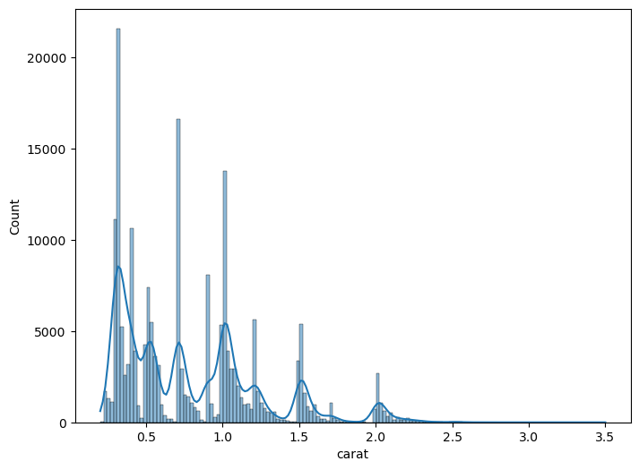

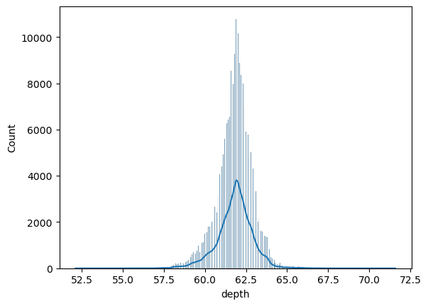

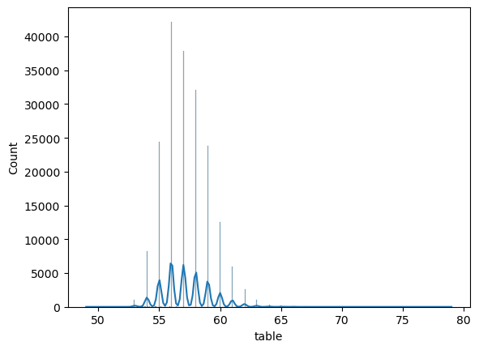

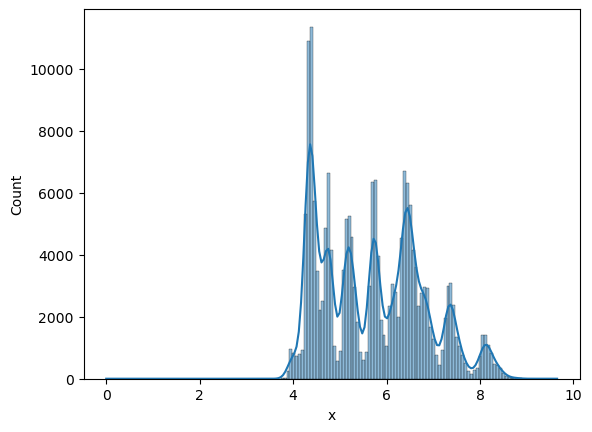

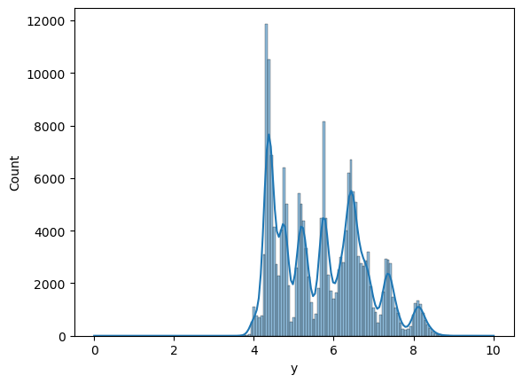

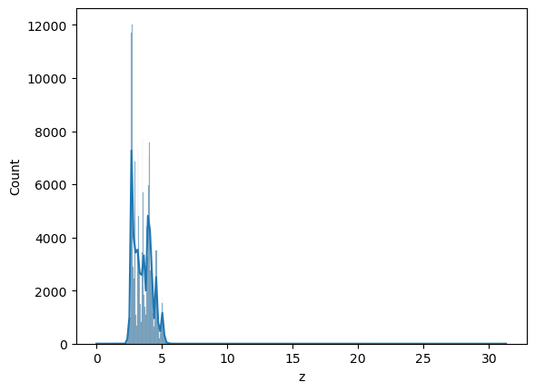

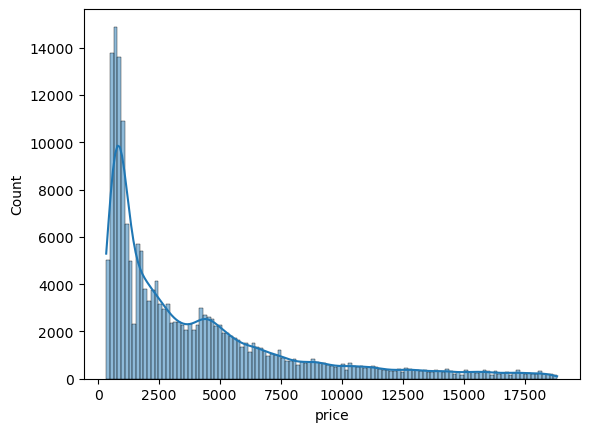

```python
import seaborn as sns
import matplotlib.pyplot as plt
plt.figure(figsize=(8,6))
x=0
for i in numerical_columns:
    sns.histplot(data=df,x=i,kde=True)
    print('\n')
    plt.show()
```

The visualizations show that most numerical features like carat, x, y, and z are right-skewed, indicating a higher number of smaller diamonds with a few large ones. Features like depth and table are more normally distributed, centered around standard diamond proportions.

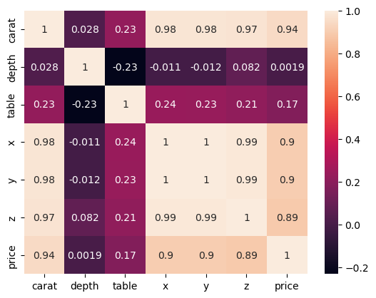

```python
# coreelation
sns.heatmap(df[numerical_columns].corr(),annot=True)
```

The heatmap shows that price is strongly correlated with carat (0.94) and physical dimensions x, y, z (≈0.90), indicating that larger diamonds tend to be more expensive. features like depth and table have very weak correlations with price

```python
# we can drop x,y,z
# df.drop(labels=['x','y','z'],axis=1)
```